# Topic 4

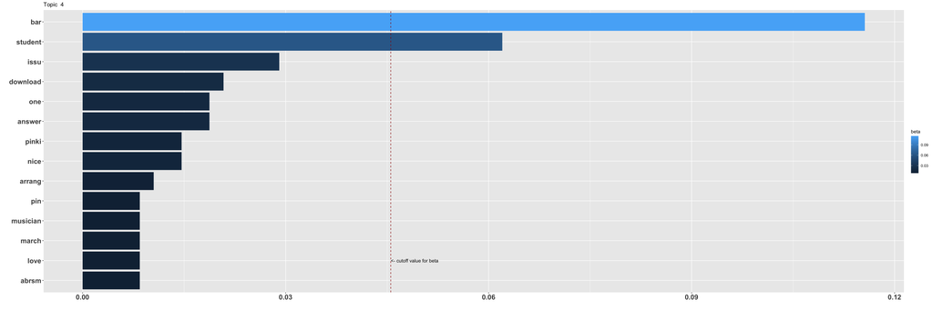

On interpreting beta: the term has a beta probability of being generated from the particular topic.

Values below are gamma : An estimated proportion of words from that document that are generated from that topic.

**Text Record Number: 203** gamma: 20 % likelihood of this document (based on its words) in this topic

**Tricky one to be honest.

Ideal answer? Your students are simply so inspired to play that they’ll practice for the love of it.

Realistic answer? Very few students will be simply desperate to play, so depending on the individual you can try a number of different things.

- A practice timetable / guide. As the person on your other post suggested, give them a weekly structure for their practice time.
- Clear goals. Concise bullet points of EXACTLY what needs to be done
- A branching tree of success. Some students will have severe difficulties with their confidence. Go with the point above but make it more of a flow chart: complete X - if you do this complete Y - if you do this complete Z. Make sure that goal X is very very manageable then uncrease the difficulty from there.
- Make sure they understand how to practice / make sure their practice is efficient. So often if I ask a student “So tell me, how did you go about practicing this piece?” They’ll either look at me completely bewildered (“I played it….duh”) or they’ll say “I played it from the beginning all the way through a few times”. Obviously the latter is not ideal and I bang my ahead against a brick wall reinforcing the importance of small sections practiced at the speed of no mistakes. To that end, often the answer isn’t that they need to practice *more* but rather to practice *more efficiently*.
- Make sure you’re not setting too much or too little. Again this is a student by student issue, it’ll vary massively. If you set them too much they’ll be overwhelmed. If you set them too little there’s no challenge, it’s easy, done in a single session. Find the balance for your student.
- Get across the importance of playing music they enjoy. This can help massively with sightreading and musicality / expression. My gateway drug to piano (as with so many pianists) was hearing something I loved and thinking "hey, I’m gonna play that no matter what it takes#.
- Try to inspire them with your own playing, although carefily not to be the sage on the stage, but rather the guide on the side. Some students respond better to this than others. Play for them occasionally to get them pumped. Sometimes this will frustrate them (“yeah you should be able to play well, you’re a teacher”) but often it’ll make them realise that the instrument is capable of far more than they first thought.

This is all my own perspective and experience as a teacher mostly of children age 6-18. You need to use your expertise to try to figure out when and where to apply each idea. These points can definitely work for adults too though, just may different framing.**

**Text Record Number: 555** gamma: 20 % likelihood of this document (based on its words) in this topic

**Perseverance is the key. Pity about the teacher situation.

When I talk to my students who have coordination issues we break every movement down.

We will make sure that we fully understand the rhythm for the right hand. Then do the same with the left. This is assuming they can already read the notes.

Next, I tend to get them to lower the lid on the piano and tap each hand rhythm on the lid. If the lid isn’t available then they just tap it on their legs.

So for example, the left hand should play 2 half notes and the right plays 4 quarter notes. I get them to tap that out until they’re really comfortable with that.

Next I take that back to the keys and add the notes this time.

It really is a case of understanding how each hand moves on it’s own AND then how they move together i.e. do they move down on to the keys at the same time? does one more down and the other one not? etc.

Get this level of understanding and you will be able to progress.**

**Text Record Number: 1039** gamma: 20 % likelihood of this document (based on its words) in this topic

**It’s until the end of a bar unless another accidental changes the note again. The confusion may be coming from the fact that publishers sometimes write a natural in the next bar where one isn’t necessary; this can help just to clarify that it’s no longer sharp or flat.**

**Text Record Number: 277** gamma: 20 % likelihood of this document (based on its words) in this topic

**In this case, I think you would continue to play the notes in bar 8 with the left hand, but you need to transpose the notes into the treble clef and then move back down with the LH to play the A in the bass clef in bar 9. So in bar 8, your LH plays: A,E, A&F&B,E,F&B,E, then in bar 9 LH: A,E,A&F,E. Usually if the piece needs you to swap hands, a little ‘M.G’ or ‘LH/RH’ is written about the note. Hope that helps :)**

**Text Record Number: 165** gamma: 20 % likelihood of this document (based on its words) in this topic

**I was in your shoes when it comes to note reading. I beat myself up everyday for not able to read notes even though I was a Grade 7 ABRSM standard. Not so sure how you read your notes but before I tried work hard on note reading, I thought I’m supposed to count the notes letter by letter. I used to count from the nearest C to get there but I was so damn wrong.

I, then looked at the notes as a series of ladders going up and down, some steps are leaps instead. And how far do I have to leap? I ask myself these questions as I work on it. I work on 2 bars each time, allowing myself to make mistakes and finish the 2 bars off, and then I’ll increase to a few more bars to even a whole piece. I bring out all of my beginner books, practicing from the easiest to the hardest.

The trick is to… Really forcing myself to just look at the music sheet and DO NOT look down on my keyboard unless I’m very sure I’m at a totally wrong pitch for a long stretch. I will try to correct myself along the way and see where it will lead me to. So by doing this, I let my fingers feel the musical intervals on the keyboard and my brain to really focus on looking and analysing the series of note. It’s very very difficult but it helped me tremendously! Hope it helps for you too!**

**Text Record Number: 655** gamma: 20 % likelihood of this document (based on its words) in this topic

**I would check out the sheet music from Payson Method… New Classics progresses from beginner to intermediate with 41 piano pieces. There are free downloads online to get started.

http://paysonmethod.com/free-resources/**

**Text Record Number: 1168** gamma: 20 % likelihood of this document (based on its words) in this topic

**I find muscle memory kicks in inevitably with all the pieces I prepare. If you repeat something enough it just goes in, whether you intend it to or not.

There’s a couple of techniques I use to halt the reliance on muscle memory. Looking at the sheet music consistently throughout the process, as much as possible. Eventually you’ll stop taking in the notes because your hands will just do it, but keep looking at the sheets for dynamic reminders etc. Learning the piece in reverse - bar by bar - also helps.**